# Risk Factor Analysis

## Outcome Variable

**Outcome Variable:** ever_stunted

## Predictor Variables

**Intervention Variable:** birthlen

**Adjustment Set:**

- arm
- W_mage
- meducyrs
- feducyrs
- vagbrth
- single
- brthmon
- W_parity
- delta_W_mage
- delta_meducyrs
- delta_feducyrs
- delta_vagbrth
- delta_single
- delta_brthmon
- delta_W_parity

## Stratifying Variables

The analysis was stratified on these variable(s):

- agecat
- studyid
- country

## Data Summary

| agecat | studyid | country | birthlen | ever_stunted | n_cell | n |
| --- | --- | --- | --- | --- | --- | --- |
| 0-24 months (no birth st.) | ki0047075b-MAL-ED | BANGLADESH | >=50 cm | 0 | 23 | 211 |
| 0-24 months (no birth st.) | ki0047075b-MAL-ED | BANGLADESH | >=50 cm | 1 | 6 | 211 |
| 0-24 months (no birth st.) | ki0047075b-MAL-ED | BANGLADESH | <48 cm | 0 | 33 | 211 |
| 0-24 months (no birth st.) | ki0047075b-MAL-ED | BANGLADESH | <48 cm | 1 | 64 | 211 |
| 0-24 months (no birth st.) | ki0047075b-MAL-ED | BANGLADESH | [48-50) cm | 0 | 45 | 211 |
| 0-24 months (no birth st.) | ki0047075b-MAL-ED | BANGLADESH | [48-50) cm | 1 | 40 | 211 |
| 0-24 months (no birth st.) | ki0047075b-MAL-ED | BRAZIL | >=50 cm | 0 | 33 | 170 |
| 0-24 months (no birth st.) | ki0047075b-MAL-ED | BRAZIL | >=50 cm | 1 | 1 | 170 |
| 0-24 months (no birth st.) | ki0047075b-MAL-ED | BRAZIL | <48 cm | 0 | 38 | 170 |
| 0-24 months (no birth st.) | ki0047075b-MAL-ED | BRAZIL | <48 cm | 1 | 21 | 170 |
| 0-24 months (no birth st.) | ki0047075b-MAL-ED | BRAZIL | [48-50) cm | 0 | 73 | 170 |
| 0-24 months (no birth st.) | ki0047075b-MAL-ED | BRAZIL | [48-50) cm | 1 | 4 | 170 |
| 0-24 months (no birth st.) | ki0047075b-MAL-ED | INDIA | >=50 cm | 0 | 21 | 174 |
| 0-24 months (no birth st.) | ki0047075b-MAL-ED | INDIA | >=50 cm | 1 | 4 | 174 |
| 0-24 months (no birth st.) | ki0047075b-MAL-ED | INDIA | <48 cm | 0 | 28 | 174 |
| 0-24 months (no birth st.) | ki0047075b-MAL-ED | INDIA | <48 cm | 1 | 47 | 174 |
| 0-24 months (no birth st.) | ki0047075b-MAL-ED | INDIA | [48-50) cm | 0 | 39 | 174 |
| 0-24 months (no birth st.) | ki0047075b-MAL-ED | INDIA | [48-50) cm | 1 | 35 | 174 |
| 0-24 months (no birth st.) | ki0047075b-MAL-ED | NEPAL | >=50 cm | 0 | 37 | 155 |
| 0-24 months (no birth st.) | ki0047075b-MAL-ED | NEPAL | >=50 cm | 1 | 1 | 155 |
| 0-24 months (no birth st.) | ki0047075b-MAL-ED | NEPAL | <48 cm | 0 | 30 | 155 |
| 0-24 months (no birth st.) | ki0047075b-MAL-ED | NEPAL | <48 cm | 1 | 21 | 155 |
| 0-24 months (no birth st.) | ki0047075b-MAL-ED | NEPAL | [48-50) cm | 0 | 48 | 155 |
| 0-24 months (no birth st.) | ki0047075b-MAL-ED | NEPAL | [48-50) cm | 1 | 18 | 155 |
| 0-24 months (no birth st.) | ki0047075b-MAL-ED | PERU | >=50 cm | 0 | 21 | 255 |
| 0-24 months (no birth st.) | ki0047075b-MAL-ED | PERU | >=50 cm | 1 | 13 | 255 |
| 0-24 months (no birth st.) | ki0047075b-MAL-ED | PERU | <48 cm | 0 | 31 | 255 |
| 0-24 months (no birth st.) | ki0047075b-MAL-ED | PERU | <48 cm | 1 | 78 | 255 |
| 0-24 months (no birth st.) | ki0047075b-MAL-ED | PERU | [48-50) cm | 0 | 58 | 255 |
| 0-24 months (no birth st.) | ki0047075b-MAL-ED | PERU | [48-50) cm | 1 | 54 | 255 |

[output cut: 468 more lines]

The following strata were considered:

- agecat: 0-24 months (no birth st.), studyid: ki0047075b-MAL-ED, country: BANGLADESH
- agecat: 0-24 months (no birth st.), studyid: ki0047075b-MAL-ED, country: BRAZIL
- agecat: 0-24 months (no birth st.), studyid: ki0047075b-MAL-ED, country: INDIA
- agecat: 0-24 months (no birth st.), studyid: ki0047075b-MAL-ED, country: NEPAL
- agecat: 0-24 months (no birth st.), studyid: ki0047075b-MAL-ED, country: PERU
- agecat: 0-24 months (no birth st.), studyid: ki0047075b-MAL-ED, country: SOUTH AFRICA
- agecat: 0-24 months (no birth st.), studyid: ki0047075b-MAL-ED, country: TANZANIA, UNITED REPUBLIC OF
- agecat: 0-24 months (no birth st.), studyid: ki1000108-CMC-V-BCS-2002, country: INDIA
- agecat: 0-24 months (no birth st.), studyid: ki1000108-IRC, country: INDIA
- agecat: 0-24 months (no birth st.), studyid: ki1000109-EE, country: PAKISTAN
- agecat: 0-24 months (no birth st.), studyid: ki1000109-ResPak, country: PAKISTAN
- agecat: 0-24 months (no birth st.), studyid: ki1000304b-SAS-CompFeed, country: INDIA
- agecat: 0-24 months (no birth st.), studyid: ki1017093-NIH-Birth, country: BANGLADESH
- agecat: 0-24 months (no birth st.), studyid: ki1017093b-PROVIDE, country: BANGLADESH
- agecat: 0-24 months (no birth st.), studyid: ki1017093c-NIH-Crypto, country: BANGLADESH
- agecat: 0-24 months (no birth st.), studyid: ki1101329-Keneba, country: GAMBIA
- agecat: 0-24 months (no birth st.), studyid: ki1114097-CMIN, country: BANGLADESH
- agecat: 0-24 months (no birth st.), studyid: ki1114097-CMIN, country: BRAZIL
- agecat: 0-24 months (no birth st.), studyid: ki1114097-CMIN, country: GUINEA-BISSAU
- agecat: 0-24 months (no birth st.), studyid: ki1114097-CMIN, country: PERU
- agecat: 0-24 months (no birth st.), studyid: ki1114097-CONTENT, country: PERU
- agecat: 0-24 months (no birth st.), studyid: ki1119695-PROBIT, country: BELARUS
- agecat: 0-24 months (no birth st.), studyid: ki1126311-ZVITAMBO, country: ZIMBABWE
- agecat: 0-24 months (no birth st.), studyid: ki1135781-COHORTS, country: GUATEMALA
- agecat: 0-24 months (no birth st.), studyid: ki1135781-COHORTS, country: INDIA
- agecat: 0-24 months (no birth st.), studyid: ki1135781-COHORTS, country: PHILIPPINES
- agecat: 0-24 months (no birth st.), studyid: kiGH5241-JiVitA-3, country: BANGLADESH
- agecat: 0-24 months (no birth st.), studyid: kiGH5241-JiVitA-4, country: BANGLADESH
- agecat: 0-6 months (no birth st.), studyid: ki0047075b-MAL-ED, country: BANGLADESH
- agecat: 0-6 months (no birth st.), studyid: ki0047075b-MAL-ED, country: BRAZIL
- agecat: 0-6 months (no birth st.), studyid: ki0047075b-MAL-ED, country: INDIA
- agecat: 0-6 months (no birth st.), studyid: ki0047075b-MAL-ED, country: NEPAL
- agecat: 0-6 months (no birth st.), studyid: ki0047075b-MAL-ED, country: PERU
- agecat: 0-6 months (no birth st.), studyid: ki0047075b-MAL-ED, country: SOUTH AFRICA
- agecat: 0-6 months (no birth st.), studyid: ki0047075b-MAL-ED, country: TANZANIA, UNITED REPUBLIC OF
- agecat: 0-6 months (no birth st.), studyid: ki1000108-CMC-V-BCS-2002, country: INDIA
- agecat: 0-6 months (no birth st.), studyid: ki1000108-IRC, country: INDIA
- agecat: 0-6 months (no birth st.), studyid: ki1000109-EE, country: PAKISTAN
- agecat: 0-6 months (no birth st.), studyid: ki1000109-ResPak, country: PAKISTAN
- agecat: 0-6 months (no birth st.), studyid: ki1000304b-SAS-CompFeed, country: INDIA
- agecat: 0-6 months (no birth st.), studyid: ki1017093-NIH-Birth, country: BANGLADESH
- agecat: 0-6 months (no birth st.), studyid: ki1017093b-PROVIDE, country: BANGLADESH
- agecat: 0-6 months (no birth st.), studyid: ki1017093c-NIH-Crypto, country: BANGLADESH
- agecat: 0-6 months (no birth st.), studyid: ki1101329-Keneba, country: GAMBIA
- agecat: 0-6 months (no birth st.), studyid: ki1114097-CMIN, country: BANGLADESH
- agecat: 0-6 months (no birth st.), studyid: ki1114097-CMIN, country: BRAZIL
- agecat: 0-6 months (no birth st.), studyid: ki1114097-CMIN, country: GUINEA-BISSAU
- agecat: 0-6 months (no birth st.), studyid: ki1114097-CMIN, country: PERU
- agecat: 0-6 months (no birth st.), studyid: ki1114097-CONTENT, country: PERU
- agecat: 0-6 months (no birth st.), studyid: ki1119695-PROBIT, country: BELARUS
- agecat: 0-6 months (no birth st.), studyid: ki1126311-ZVITAMBO, country: ZIMBABWE
- agecat: 0-6 months (no birth st.), studyid: ki1135781-COHORTS, country: GUATEMALA
- agecat: 0-6 months (no birth st.), studyid: ki1135781-COHORTS, country: INDIA
- agecat: 0-6 months (no birth st.), studyid: ki1135781-COHORTS, country: PHILIPPINES
- agecat: 0-6 months (no birth st.), studyid: kiGH5241-JiVitA-3, country: BANGLADESH
- agecat: 0-6 months (no birth st.), studyid: kiGH5241-JiVitA-4, country: BANGLADESH
- agecat: 6-24 months, studyid: ki0047075b-MAL-ED, country: BANGLADESH
- agecat: 6-24 months, studyid: ki0047075b-MAL-ED, country: BRAZIL
- agecat: 6-24 months, studyid: ki0047075b-MAL-ED, country: INDIA
- agecat: 6-24 months, studyid: ki0047075b-MAL-ED, country: NEPAL
- agecat: 6-24 months, studyid: ki0047075b-MAL-ED, country: PERU
- agecat: 6-24 months, studyid: ki0047075b-MAL-ED, country: SOUTH AFRICA
- agecat: 6-24 months, studyid: ki0047075b-MAL-ED, country: TANZANIA, UNITED REPUBLIC OF
- agecat: 6-24 months, studyid: ki1000108-CMC-V-BCS-2002, country: INDIA
- agecat: 6-24 months, studyid: ki1000108-IRC, country: INDIA
- agecat: 6-24 months, studyid: ki1000109-EE, country: PAKISTAN
- agecat: 6-24 months, studyid: ki1000109-ResPak, country: PAKISTAN
- agecat: 6-24 months, studyid: ki1000304b-SAS-CompFeed, country: INDIA
- agecat: 6-24 months, studyid: ki1017093-NIH-Birth, country: BANGLADESH
- agecat: 6-24 months, studyid: ki1017093b-PROVIDE, country: BANGLADESH
- agecat: 6-24 months, studyid: ki1017093c-NIH-Crypto, country: BANGLADESH
- agecat: 6-24 months, studyid: ki1101329-Keneba, country: GAMBIA
- agecat: 6-24 months, studyid: ki1114097-CMIN, country: BRAZIL
- agecat: 6-24 months, studyid: ki1114097-CMIN, country: GUINEA-BISSAU
- agecat: 6-24 months, studyid: ki1114097-CMIN, country: PERU
- agecat: 6-24 months, studyid: ki1114097-CONTENT, country: PERU
- agecat: 6-24 months, studyid: ki1119695-PROBIT, country: BELARUS
- agecat: 6-24 months, studyid: ki1126311-ZVITAMBO, country: ZIMBABWE
- agecat: 6-24 months, studyid: ki1135781-COHORTS, country: GUATEMALA
- agecat: 6-24 months, studyid: ki1135781-COHORTS, country: INDIA
- agecat: 6-24 months, studyid: ki1135781-COHORTS, country: PHILIPPINES
- agecat: 6-24 months, studyid: kiGH5241-JiVitA-3, country: BANGLADESH
- agecat: 6-24 months, studyid: kiGH5241-JiVitA-4, country: BANGLADESH

### Dropped Strata

Some strata were dropped due to rare outcomes:

- agecat: 0-24 months (no birth st.), studyid: ki0047075b-MAL-ED, country: BRAZIL
- agecat: 0-24 months (no birth st.), studyid: ki0047075b-MAL-ED, country: INDIA
- agecat: 0-24 months (no birth st.), studyid: ki0047075b-MAL-ED, country: NEPAL
- agecat: 0-24 months (no birth st.), studyid: ki1000108-CMC-V-BCS-2002, country: INDIA
- agecat: 0-24 months (no birth st.), studyid: ki1000109-EE, country: PAKISTAN
- agecat: 0-24 months (no birth st.), studyid: ki1000109-ResPak, country: PAKISTAN
- agecat: 0-24 months (no birth st.), studyid: ki1114097-CMIN, country: BANGLADESH
- agecat: 0-24 months (no birth st.), studyid: ki1114097-CMIN, country: GUINEA-BISSAU
- agecat: 0-24 months (no birth st.), studyid: ki1114097-CMIN, country: PERU
- agecat: 0-24 months (no birth st.), studyid: ki1114097-CONTENT, country: PERU
- agecat: 0-6 months (no birth st.), studyid: ki0047075b-MAL-ED, country: BANGLADESH
- agecat: 0-6 months (no birth st.), studyid: ki0047075b-MAL-ED, country: BRAZIL
- agecat: 0-6 months (no birth st.), studyid: ki0047075b-MAL-ED, country: INDIA
- agecat: 0-6 months (no birth st.), studyid: ki0047075b-MAL-ED, country: NEPAL
- agecat: 0-6 months (no birth st.), studyid: ki0047075b-MAL-ED, country: PERU
- agecat: 0-6 months (no birth st.), studyid: ki0047075b-MAL-ED, country: TANZANIA, UNITED REPUBLIC OF
- agecat: 0-6 months (no birth st.), studyid: ki1000109-EE, country: PAKISTAN
- agecat: 0-6 months (no birth st.), studyid: ki1000109-ResPak, country: PAKISTAN
- agecat: 0-6 months (no birth st.), studyid: ki1017093-NIH-Birth, country: BANGLADESH
- agecat: 0-6 months (no birth st.), studyid: ki1017093b-PROVIDE, country: BANGLADESH
- agecat: 0-6 months (no birth st.), studyid: ki1017093c-NIH-Crypto, country: BANGLADESH
- agecat: 0-6 months (no birth st.), studyid: ki1114097-CMIN, country: BANGLADESH
- agecat: 0-6 months (no birth st.), studyid: ki1114097-CMIN, country: BRAZIL
- agecat: 0-6 months (no birth st.), studyid: ki1114097-CMIN, country: GUINEA-BISSAU
- agecat: 0-6 months (no birth st.), studyid: ki1114097-CMIN, country: PERU
- agecat: 0-6 months (no birth st.), studyid: ki1114097-CONTENT, country: PERU
- agecat: 6-24 months, studyid: ki0047075b-MAL-ED, country: BRAZIL
- agecat: 6-24 months, studyid: ki0047075b-MAL-ED, country: INDIA
- agecat: 6-24 months, studyid: ki0047075b-MAL-ED, country: NEPAL
- agecat: 6-24 months, studyid: ki0047075b-MAL-ED, country: TANZANIA, UNITED REPUBLIC OF
- agecat: 6-24 months, studyid: ki1000108-CMC-V-BCS-2002, country: INDIA
- agecat: 6-24 months, studyid: ki1000109-EE, country: PAKISTAN
- agecat: 6-24 months, studyid: ki1000109-ResPak, country: PAKISTAN
- agecat: 6-24 months, studyid: ki1114097-CMIN, country: BRAZIL
- agecat: 6-24 months, studyid: ki1114097-CMIN, country: GUINEA-BISSAU
- agecat: 6-24 months, studyid: ki1114097-CMIN, country: PERU
- agecat: 6-24 months, studyid: ki1114097-CONTENT, country: PERU

## Methods Detail

We’re interested in the causal parameters $E[Y_a]$ for all values of $a \in \mathcal{A}$. These parameters represent the mean outcome if, possibly contrary to fact, we intervened to set all units to have $A=a$. Under the randomization and positivity assumptions, these are identified by the statistical parameters $\psi_a=E_W[E_{Y|A,W}(Y|A=a,W)]$. In addition, we’re interested in the mean of $Y$, $E[Y]$ under no intervention (the observed mean). We will estimate these parameters by using SuperLearner to fit the relevant likelihood factors – $E_{Y|A,W}(Y|A=a,W)$ and $p(A=a|W)$, and then updating our likelihood fit using a joint TMLE.

For unadjusted analyses ($W=\{\}$), initial likelihoods were estimated using Lrnr_glm to estimate the simple $E(Y|A)$ and Lrnr_mean to estimate $p(A)$. For adjusted analyses, a small library containing Lrnr_glmnet, Lrnr_xgboost, and Lrnr_mean was used.

Having estimated these parameters, we will then use the delta method to estimate relative risks and attributable risks relative to a prespecified baseline level of $A$.

# Results Detail

## Results Plots

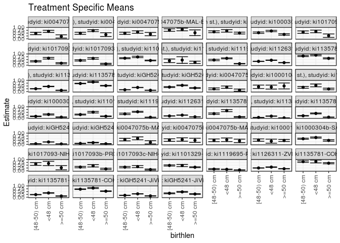

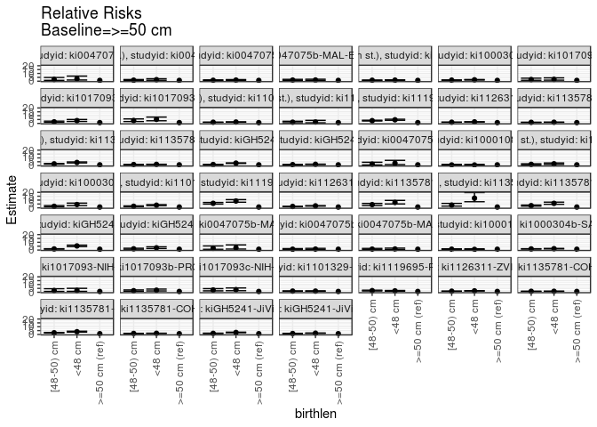

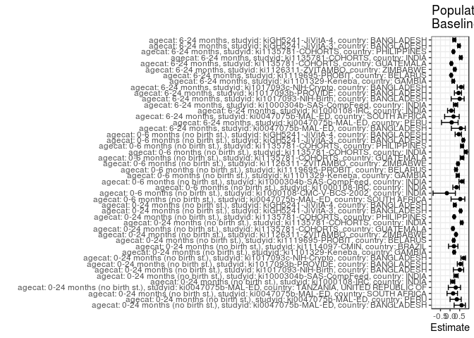

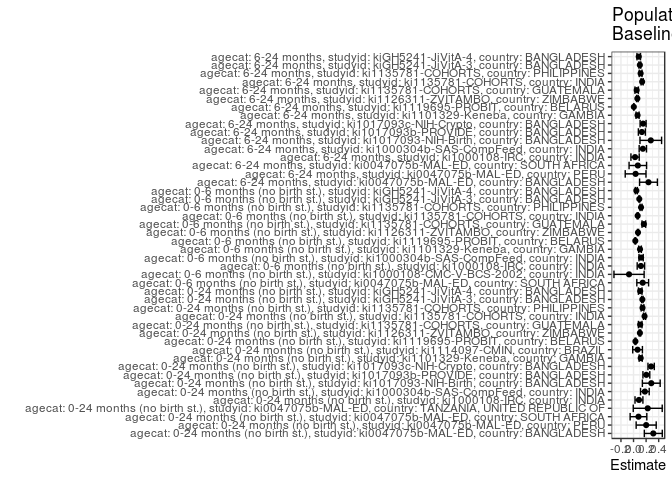

## Results Table

### Parameter: TSM

| agecat | studyid | country | intervention_level | baseline_level | estimate | ci_lower | ci_upper |
| --- | --- | --- | --- | --- | --- | --- | --- |
| 0-24 months (no birth st.) | ki0047075b-MAL-ED | BANGLADESH | >=50 cm | NA | 0.2068966 | 0.0591143 | 0.3546788 |
| 0-24 months (no birth st.) | ki0047075b-MAL-ED | BANGLADESH | <48 cm | NA | 0.6597938 | 0.5652857 | 0.7543019 |
| 0-24 months (no birth st.) | ki0047075b-MAL-ED | BANGLADESH | [48-50) cm | NA | 0.4705882 | 0.3642260 | 0.5769505 |
| 0-24 months (no birth st.) | ki0047075b-MAL-ED | PERU | >=50 cm | NA | 0.3674182 | 0.1976490 | 0.5371874 |
| 0-24 months (no birth st.) | ki0047075b-MAL-ED | PERU | <48 cm | NA | 0.7183635 | 0.6316659 | 0.8050611 |
| 0-24 months (no birth st.) | ki0047075b-MAL-ED | PERU | [48-50) cm | NA | 0.4861872 | 0.3926824 | 0.5796920 |
| 0-24 months (no birth st.) | ki0047075b-MAL-ED | SOUTH AFRICA | >=50 cm | NA | 0.4170637 | 0.2708539 | 0.5632734 |
| 0-24 months (no birth st.) | ki0047075b-MAL-ED | SOUTH AFRICA | <48 cm | NA | 0.5973134 | 0.4894170 | 0.7052098 |
| 0-24 months (no birth st.) | ki0047075b-MAL-ED | SOUTH AFRICA | [48-50) cm | NA | 0.4877923 | 0.3910150 | 0.5845697 |
| 0-24 months (no birth st.) | ki0047075b-MAL-ED | TANZANIA, UNITED REPUBLIC OF | >=50 cm | NA | 0.5333333 | 0.2796890 | 0.7869777 |
| 0-24 months (no birth st.) | ki0047075b-MAL-ED | TANZANIA, UNITED REPUBLIC OF | <48 cm | NA | 0.8250000 | 0.7067002 | 0.9432998 |
| 0-24 months (no birth st.) | ki0047075b-MAL-ED | TANZANIA, UNITED REPUBLIC OF | [48-50) cm | NA | 0.7735849 | 0.6603874 | 0.8867824 |
| 0-24 months (no birth st.) | ki1000108-IRC | INDIA | >=50 cm | NA | 0.5049895 | 0.4222169 | 0.5877620 |
| 0-24 months (no birth st.) | ki1000108-IRC | INDIA | <48 cm | NA | 0.6998059 | 0.5874684 | 0.8121433 |
| 0-24 months (no birth st.) | ki1000108-IRC | INDIA | [48-50) cm | NA | 0.6234297 | 0.5419056 | 0.7049538 |
| 0-24 months (no birth st.) | ki1000304b-SAS-CompFeed | INDIA | >=50 cm | NA | 0.3852466 | 0.3203236 | 0.4501696 |
| 0-24 months (no birth st.) | ki1000304b-SAS-CompFeed | INDIA | <48 cm | NA | 0.6897223 | 0.6299946 | 0.7494500 |
| 0-24 months (no birth st.) | ki1000304b-SAS-CompFeed | INDIA | [48-50) cm | NA | 0.5386179 | 0.4737854 | 0.6034504 |
| 0-24 months (no birth st.) | ki1017093-NIH-Birth | BANGLADESH | >=50 cm | NA | 0.2727273 | 0.1203569 | 0.4250976 |
| 0-24 months (no birth st.) | ki1017093-NIH-Birth | BANGLADESH | <48 cm | NA | 0.6515152 | 0.5362424 | 0.7667879 |
| 0-24 months (no birth st.) | ki1017093-NIH-Birth | BANGLADESH | [48-50) cm | NA | 0.5903614 | 0.4842738 | 0.6964491 |
| 0-24 months (no birth st.) | ki1017093b-PROVIDE | BANGLADESH | >=50 cm | NA | 0.1714582 | 0.1142024 | 0.2287140 |
| 0-24 months (no birth st.) | ki1017093b-PROVIDE | BANGLADESH | <48 cm | NA | 0.6154449 | 0.5439598 | 0.6869301 |
| 0-24 months (no birth st.) | ki1017093b-PROVIDE | BANGLADESH | [48-50) cm | NA | 0.3451746 | 0.2894925 | 0.4008567 |
| 0-24 months (no birth st.) | ki1017093c-NIH-Crypto | BANGLADESH | >=50 cm | NA | 0.1136521 | 0.0653649 | 0.1619394 |
| 0-24 months (no birth st.) | ki1017093c-NIH-Crypto | BANGLADESH | <48 cm | NA | 0.5994833 | 0.5286475 | 0.6703191 |
| 0-24 months (no birth st.) | ki1017093c-NIH-Crypto | BANGLADESH | [48-50) cm | NA | 0.4235376 | 0.3672375 | 0.4798377 |
| 0-24 months (no birth st.) | ki1101329-Keneba | GAMBIA | >=50 cm | NA | 0.4156397 | 0.3807067 | 0.4505728 |
| 0-24 months (no birth st.) | ki1101329-Keneba | GAMBIA | <48 cm | NA | 0.7299389 | 0.6693499 | 0.7905279 |
| 0-24 months (no birth st.) | ki1101329-Keneba | GAMBIA | [48-50) cm | NA | 0.6199892 | 0.5778280 | 0.6621505 |

[output cut: 108 more lines]

### Parameter: E(Y)

| agecat | studyid | country | intervention_level | baseline_level | estimate | ci_lower | ci_upper |
| --- | --- | --- | --- | --- | --- | --- | --- |
| 0-24 months (no birth st.) | ki0047075b-MAL-ED | BANGLADESH | NA | NA | 0.5213270 | 0.4537634 | 0.5888907 |
| 0-24 months (no birth st.) | ki0047075b-MAL-ED | PERU | NA | NA | 0.5686275 | 0.5077199 | 0.6295350 |
| 0-24 months (no birth st.) | ki0047075b-MAL-ED | SOUTH AFRICA | NA | NA | 0.4957265 | 0.4315281 | 0.5599249 |
| 0-24 months (no birth st.) | ki0047075b-MAL-ED | TANZANIA, UNITED REPUBLIC OF | NA | NA | 0.7592593 | 0.6782516 | 0.8402669 |
| 0-24 months (no birth st.) | ki1000108-IRC | INDIA | NA | NA | 0.5913043 | 0.5393557 | 0.6432530 |
| 0-24 months (no birth st.) | ki1000304b-SAS-CompFeed | INDIA | NA | NA | 0.5657407 | 0.5074689 | 0.6240126 |
| 0-24 months (no birth st.) | ki1017093-NIH-Birth | BANGLADESH | NA | NA | 0.5549451 | 0.4825447 | 0.6273454 |
| 0-24 months (no birth st.) | ki1017093b-PROVIDE | BANGLADESH | NA | NA | 0.3753943 | 0.3376725 | 0.4131162 |
| 0-24 months (no birth st.) | ki1017093c-NIH-Crypto | BANGLADESH | NA | NA | 0.3935681 | 0.3560687 | 0.4310676 |
| 0-24 months (no birth st.) | ki1101329-Keneba | GAMBIA | NA | NA | 0.5296120 | 0.5040796 | 0.5551444 |
| 0-24 months (no birth st.) | ki1114097-CMIN | BRAZIL | NA | NA | 0.3181818 | 0.2307425 | 0.4056211 |
| 0-24 months (no birth st.) | ki1119695-PROBIT | BELARUS | NA | NA | 0.1597778 | 0.1408215 | 0.1787342 |
| 0-24 months (no birth st.) | ki1126311-ZVITAMBO | ZIMBABWE | NA | NA | 0.3260417 | 0.3178171 | 0.3342662 |
| 0-24 months (no birth st.) | ki1135781-COHORTS | GUATEMALA | NA | NA | 0.7082294 | 0.6767491 | 0.7397098 |
| 0-24 months (no birth st.) | ki1135781-COHORTS | INDIA | NA | NA | 0.2867647 | 0.2751726 | 0.2983568 |
| 0-24 months (no birth st.) | ki1135781-COHORTS | PHILIPPINES | NA | NA | 0.6671324 | 0.6498678 | 0.6843969 |
| 0-24 months (no birth st.) | kiGH5241-JiVitA-3 | BANGLADESH | NA | NA | 0.2544613 | 0.2465893 | 0.2623333 |
| 0-24 months (no birth st.) | kiGH5241-JiVitA-4 | BANGLADESH | NA | NA | 0.4273585 | 0.4069266 | 0.4477904 |
| 0-6 months (no birth st.) | ki0047075b-MAL-ED | SOUTH AFRICA | NA | NA | 0.2735043 | 0.2162683 | 0.3307402 |
| 0-6 months (no birth st.) | ki1000108-CMC-V-BCS-2002 | INDIA | NA | NA | 0.4285714 | 0.3221077 | 0.5350351 |
| 0-6 months (no birth st.) | ki1000108-IRC | INDIA | NA | NA | 0.3478261 | 0.2974955 | 0.3981566 |
| 0-6 months (no birth st.) | ki1000304b-SAS-CompFeed | INDIA | NA | NA | 0.1946247 | 0.1703263 | 0.2189230 |
| 0-6 months (no birth st.) | ki1101329-Keneba | GAMBIA | NA | NA | 0.2552757 | 0.2329715 | 0.2775799 |
| 0-6 months (no birth st.) | ki1119695-PROBIT | BELARUS | NA | NA | 0.0912784 | 0.0781588 | 0.1043979 |
| 0-6 months (no birth st.) | ki1126311-ZVITAMBO | ZIMBABWE | NA | NA | 0.1716896 | 0.1650721 | 0.1783072 |
| 0-6 months (no birth st.) | ki1135781-COHORTS | GUATEMALA | NA | NA | 0.2581047 | 0.2278007 | 0.2884088 |
| 0-6 months (no birth st.) | ki1135781-COHORTS | INDIA | NA | NA | 0.0790014 | 0.0720874 | 0.0859154 |
| 0-6 months (no birth st.) | ki1135781-COHORTS | PHILIPPINES | NA | NA | 0.1893119 | 0.1749594 | 0.2036645 |
| 0-6 months (no birth st.) | kiGH5241-JiVitA-3 | BANGLADESH | NA | NA | 0.1321472 | 0.1264309 | 0.1378635 |
| 0-6 months (no birth st.) | kiGH5241-JiVitA-4 | BANGLADESH | NA | NA | 0.0984277 | 0.0855770 | 0.1112784 |
| 6-24 months | ki0047075b-MAL-ED | BANGLADESH | NA | NA | 0.4230769 | 0.3453000 | 0.5008539 |
| 6-24 months | ki0047075b-MAL-ED | PERU | NA | NA | 0.3958333 | 0.3156813 | 0.4759854 |
| 6-24 months | ki0047075b-MAL-ED | SOUTH AFRICA | NA | NA | 0.3795620 | 0.2980035 | 0.4611205 |
| 6-24 months | ki1000108-IRC | INDIA | NA | NA | 0.3733333 | 0.3099915 | 0.4366752 |
| 6-24 months | ki1000304b-SAS-CompFeed | INDIA | NA | NA | 0.5006242 | 0.4555100 | 0.5457384 |
| 6-24 months | ki1017093-NIH-Birth | BANGLADESH | NA | NA | 0.5471698 | 0.4519599 | 0.6423797 |
| 6-24 months | ki1017093b-PROVIDE | BANGLADESH | NA | NA | 0.2997812 | 0.2577294 | 0.3418330 |
| 6-24 months | ki1017093c-NIH-Crypto | BANGLADESH | NA | NA | 0.2628458 | 0.2244546 | 0.3012371 |
| 6-24 months | ki1101329-Keneba | GAMBIA | NA | NA | 0.3816288 | 0.3523153 | 0.4109422 |
| 6-24 months | ki1119695-PROBIT | BELARUS | NA | NA | 0.0768510 | 0.0628857 | 0.0908164 |
| 6-24 months | ki1126311-ZVITAMBO | ZIMBABWE | NA | NA | 0.2452926 | 0.2357801 | 0.2548051 |
| 6-24 months | ki1135781-COHORTS | GUATEMALA | NA | NA | 0.7234469 | 0.6841620 | 0.7627318 |
| 6-24 months | ki1135781-COHORTS | INDIA | NA | NA | 0.2424242 | 0.2305635 | 0.2542850 |
| 6-24 months | ki1135781-COHORTS | PHILIPPINES | NA | NA | 0.6465028 | 0.6261291 | 0.6668766 |
| 6-24 months | kiGH5241-JiVitA-3 | BANGLADESH | NA | NA | 0.2160248 | 0.2065944 | 0.2254552 |
| 6-24 months | kiGH5241-JiVitA-4 | BANGLADESH | NA | NA | 0.3663989 | 0.3454886 | 0.3873091 |

### Parameter: RR

| agecat | studyid | country | intervention_level | baseline_level | estimate | ci_lower | ci_upper |
| --- | --- | --- | --- | --- | --- | --- | --- |
| 0-24 months (no birth st.) | ki0047075b-MAL-ED | BANGLADESH | >=50 cm | >=50 cm | 1.0000000 | 1.0000000 | 1.000000 |
| 0-24 months (no birth st.) | ki0047075b-MAL-ED | BANGLADESH | <48 cm | >=50 cm | 3.1890034 | 1.5391141 | 6.607530 |
| 0-24 months (no birth st.) | ki0047075b-MAL-ED | BANGLADESH | [48-50) cm | >=50 cm | 2.2745098 | 1.0752756 | 4.811227 |
| 0-24 months (no birth st.) | ki0047075b-MAL-ED | PERU | >=50 cm | >=50 cm | 1.0000000 | 1.0000000 | 1.000000 |
| 0-24 months (no birth st.) | ki0047075b-MAL-ED | PERU | <48 cm | >=50 cm | 1.9551659 | 1.2132704 | 3.150719 |
| 0-24 months (no birth st.) | ki0047075b-MAL-ED | PERU | [48-50) cm | >=50 cm | 1.3232529 | 0.8023198 | 2.182419 |
| 0-24 months (no birth st.) | ki0047075b-MAL-ED | SOUTH AFRICA | >=50 cm | >=50 cm | 1.0000000 | 1.0000000 | 1.000000 |
| 0-24 months (no birth st.) | ki0047075b-MAL-ED | SOUTH AFRICA | <48 cm | >=50 cm | 1.4321875 | 0.9644092 | 2.126858 |
| 0-24 months (no birth st.) | ki0047075b-MAL-ED | SOUTH AFRICA | [48-50) cm | >=50 cm | 1.1695872 | 0.7813367 | 1.750761 |
| 0-24 months (no birth st.) | ki0047075b-MAL-ED | TANZANIA, UNITED REPUBLIC OF | >=50 cm | >=50 cm | 1.0000000 | 1.0000000 | 1.000000 |
| 0-24 months (no birth st.) | ki0047075b-MAL-ED | TANZANIA, UNITED REPUBLIC OF | <48 cm | >=50 cm | 1.5468750 | 0.9412997 | 2.542041 |
| 0-24 months (no birth st.) | ki0047075b-MAL-ED | TANZANIA, UNITED REPUBLIC OF | [48-50) cm | >=50 cm | 1.4504717 | 0.8818823 | 2.385657 |
| 0-24 months (no birth st.) | ki1000108-IRC | INDIA | >=50 cm | >=50 cm | 1.0000000 | 1.0000000 | 1.000000 |
| 0-24 months (no birth st.) | ki1000108-IRC | INDIA | <48 cm | >=50 cm | 1.3857831 | 1.1019271 | 1.742760 |
| 0-24 months (no birth st.) | ki1000108-IRC | INDIA | [48-50) cm | >=50 cm | 1.2345401 | 1.0014438 | 1.521892 |
| 0-24 months (no birth st.) | ki1000304b-SAS-CompFeed | INDIA | >=50 cm | >=50 cm | 1.0000000 | 1.0000000 | 1.000000 |
| 0-24 months (no birth st.) | ki1000304b-SAS-CompFeed | INDIA | <48 cm | >=50 cm | 1.7903397 | 1.4872876 | 2.155142 |
| 0-24 months (no birth st.) | ki1000304b-SAS-CompFeed | INDIA | [48-50) cm | >=50 cm | 1.3981121 | 1.1750065 | 1.663580 |
| 0-24 months (no birth st.) | ki1017093-NIH-Birth | BANGLADESH | >=50 cm | >=50 cm | 1.0000000 | 1.0000000 | 1.000000 |
| 0-24 months (no birth st.) | ki1017093-NIH-Birth | BANGLADESH | <48 cm | >=50 cm | 2.3888889 | 1.3294836 | 4.292486 |
| 0-24 months (no birth st.) | ki1017093-NIH-Birth | BANGLADESH | [48-50) cm | >=50 cm | 2.1646586 | 1.2036793 | 3.892854 |
| 0-24 months (no birth st.) | ki1017093b-PROVIDE | BANGLADESH | >=50 cm | >=50 cm | 1.0000000 | 1.0000000 | 1.000000 |
| 0-24 months (no birth st.) | ki1017093b-PROVIDE | BANGLADESH | <48 cm | >=50 cm | 3.5894749 | 2.5199973 | 5.112835 |
| 0-24 months (no birth st.) | ki1017093b-PROVIDE | BANGLADESH | [48-50) cm | >=50 cm | 2.0131703 | 1.3886013 | 2.918660 |
| 0-24 months (no birth st.) | ki1017093c-NIH-Crypto | BANGLADESH | >=50 cm | >=50 cm | 1.0000000 | 1.0000000 | 1.000000 |
| 0-24 months (no birth st.) | ki1017093c-NIH-Crypto | BANGLADESH | <48 cm | >=50 cm | 5.2747213 | 3.3939000 | 8.197850 |
| 0-24 months (no birth st.) | ki1017093c-NIH-Crypto | BANGLADESH | [48-50) cm | >=50 cm | 3.7266138 | 2.3883577 | 5.814728 |
| 0-24 months (no birth st.) | ki1101329-Keneba | GAMBIA | >=50 cm | >=50 cm | 1.0000000 | 1.0000000 | 1.000000 |
| 0-24 months (no birth st.) | ki1101329-Keneba | GAMBIA | <48 cm | >=50 cm | 1.7561816 | 1.5611614 | 1.975564 |
| 0-24 months (no birth st.) | ki1101329-Keneba | GAMBIA | [48-50) cm | >=50 cm | 1.4916505 | 1.3398985 | 1.660589 |

[output cut: 108 more lines]

### Parameter: PAR

| agecat | studyid | country | intervention_level | baseline_level | estimate | ci_lower | ci_upper |
| --- | --- | --- | --- | --- | --- | --- | --- |
| 0-24 months (no birth st.) | ki0047075b-MAL-ED | BANGLADESH | >=50 cm | NA | 0.3144305 | 0.1715979 | 0.4572630 |
| 0-24 months (no birth st.) | ki0047075b-MAL-ED | PERU | >=50 cm | NA | 0.2012093 | 0.0416946 | 0.3607239 |
| 0-24 months (no birth st.) | ki0047075b-MAL-ED | SOUTH AFRICA | >=50 cm | NA | 0.0786628 | -0.0540710 | 0.2113966 |
| 0-24 months (no birth st.) | ki0047075b-MAL-ED | TANZANIA, UNITED REPUBLIC OF | >=50 cm | NA | 0.2259259 | -0.0043494 | 0.4562013 |
| 0-24 months (no birth st.) | ki1000108-IRC | INDIA | >=50 cm | NA | 0.0863149 | 0.0235768 | 0.1490529 |
| 0-24 months (no birth st.) | ki1000304b-SAS-CompFeed | INDIA | >=50 cm | NA | 0.1804942 | 0.1116845 | 0.2493039 |
| 0-24 months (no birth st.) | ki1017093-NIH-Birth | BANGLADESH | >=50 cm | NA | 0.2822178 | 0.1406576 | 0.4237780 |
| 0-24 months (no birth st.) | ki1017093b-PROVIDE | BANGLADESH | >=50 cm | NA | 0.2039361 | 0.1494537 | 0.2584185 |
| 0-24 months (no birth st.) | ki1017093c-NIH-Crypto | BANGLADESH | >=50 cm | NA | 0.2799160 | 0.2294385 | 0.3303936 |
| 0-24 months (no birth st.) | ki1101329-Keneba | GAMBIA | >=50 cm | NA | 0.1139722 | 0.0896173 | 0.1383272 |
| 0-24 months (no birth st.) | ki1114097-CMIN | BRAZIL | >=50 cm | NA | 0.0642136 | -0.0129213 | 0.1413485 |
| 0-24 months (no birth st.) | ki1119695-PROBIT | BELARUS | >=50 cm | NA | 0.0303208 | 0.0233063 | 0.0373353 |
| 0-24 months (no birth st.) | ki1126311-ZVITAMBO | ZIMBABWE | >=50 cm | NA | 0.1013935 | 0.0903250 | 0.1124620 |
| 0-24 months (no birth st.) | ki1135781-COHORTS | GUATEMALA | >=50 cm | NA | 0.1061223 | 0.0776746 | 0.1345700 |
| 0-24 months (no birth st.) | ki1135781-COHORTS | INDIA | >=50 cm | NA | 0.1750501 | 0.1586399 | 0.1914603 |
| 0-24 months (no birth st.) | ki1135781-COHORTS | PHILIPPINES | >=50 cm | NA | 0.1428652 | 0.1212304 | 0.1645000 |
| 0-24 months (no birth st.) | kiGH5241-JiVitA-3 | BANGLADESH | >=50 cm | NA | 0.1402632 | 0.1291364 | 0.1513900 |
| 0-24 months (no birth st.) | kiGH5241-JiVitA-4 | BANGLADESH | >=50 cm | NA | 0.1061571 | 0.0776118 | 0.1347024 |
| 0-6 months (no birth st.) | ki0047075b-MAL-ED | SOUTH AFRICA | >=50 cm | NA | 0.1458447 | 0.0523301 | 0.2393593 |
| 0-6 months (no birth st.) | ki1000108-CMC-V-BCS-2002 | INDIA | >=50 cm | NA | -0.0714286 | -0.3114643 | 0.1686072 |
| 0-6 months (no birth st.) | ki1000108-IRC | INDIA | >=50 cm | NA | 0.1171146 | 0.0580901 | 0.1761391 |
| 0-6 months (no birth st.) | ki1000304b-SAS-CompFeed | INDIA | >=50 cm | NA | 0.1204686 | 0.0868480 | 0.1540892 |
| 0-6 months (no birth st.) | ki1101329-Keneba | GAMBIA | >=50 cm | NA | 0.1030364 | 0.0813208 | 0.1247521 |
| 0-6 months (no birth st.) | ki1119695-PROBIT | BELARUS | >=50 cm | NA | 0.0284769 | 0.0224498 | 0.0345040 |
| 0-6 months (no birth st.) | ki1126311-ZVITAMBO | ZIMBABWE | >=50 cm | NA | 0.0710250 | 0.0625045 | 0.0795455 |
| 0-6 months (no birth st.) | ki1135781-COHORTS | GUATEMALA | >=50 cm | NA | 0.1640669 | 0.1349243 | 0.1932096 |
| 0-6 months (no birth st.) | ki1135781-COHORTS | INDIA | >=50 cm | NA | 0.0657265 | 0.0576126 | 0.0738405 |
| 0-6 months (no birth st.) | ki1135781-COHORTS | PHILIPPINES | >=50 cm | NA | 0.1194482 | 0.1035648 | 0.1353317 |
| 0-6 months (no birth st.) | kiGH5241-JiVitA-3 | BANGLADESH | >=50 cm | NA | 0.0916200 | 0.0842121 | 0.0990279 |
| 0-6 months (no birth st.) | kiGH5241-JiVitA-4 | BANGLADESH | >=50 cm | NA | 0.0447015 | 0.0283119 | 0.0610910 |
| 6-24 months | ki0047075b-MAL-ED | BANGLADESH | >=50 cm | NA | 0.2378917 | 0.0958468 | 0.3799367 |
| 6-24 months | ki0047075b-MAL-ED | PERU | >=50 cm | NA | 0.0330868 | -0.1320921 | 0.1982657 |
| 6-24 months | ki0047075b-MAL-ED | SOUTH AFRICA | >=50 cm | NA | 0.0682402 | -0.0710266 | 0.2075069 |
| 6-24 months | ki1000108-IRC | INDIA | >=50 cm | NA | 0.0244419 | -0.0414069 | 0.0902907 |
| 6-24 months | ki1000304b-SAS-CompFeed | INDIA | >=50 cm | NA | 0.1479791 | 0.0896063 | 0.2063519 |
| 6-24 months | ki1017093-NIH-Birth | BANGLADESH | >=50 cm | NA | 0.2744425 | 0.1026423 | 0.4462428 |
| 6-24 months | ki1017093b-PROVIDE | BANGLADESH | >=50 cm | NA | 0.1327320 | 0.0767866 | 0.1886773 |
| 6-24 months | ki1017093c-NIH-Crypto | BANGLADESH | >=50 cm | NA | 0.1520662 | 0.1044379 | 0.1996945 |
| 6-24 months | ki1101329-Keneba | GAMBIA | >=50 cm | NA | 0.0639340 | 0.0396848 | 0.0881832 |
| 6-24 months | ki1119695-PROBIT | BELARUS | >=50 cm | NA | 0.0045550 | 0.0017845 | 0.0073256 |
| 6-24 months | ki1126311-ZVITAMBO | ZIMBABWE | >=50 cm | NA | 0.0607752 | 0.0484220 | 0.0731284 |
| 6-24 months | ki1135781-COHORTS | GUATEMALA | >=50 cm | NA | 0.0496664 | 0.0226156 | 0.0767172 |
| 6-24 months | ki1135781-COHORTS | INDIA | >=50 cm | NA | 0.1367428 | 0.1203549 | 0.1531308 |
| 6-24 months | ki1135781-COHORTS | PHILIPPINES | >=50 cm | NA | 0.1126128 | 0.0904044 | 0.1348212 |
| 6-24 months | kiGH5241-JiVitA-3 | BANGLADESH | >=50 cm | NA | 0.1005566 | 0.0865024 | 0.1146107 |
| 6-24 months | kiGH5241-JiVitA-4 | BANGLADESH | >=50 cm | NA | 0.0826837 | 0.0545470 | 0.1108204 |

### Parameter: PAF

| agecat | studyid | country | intervention_level | baseline_level | estimate | ci_lower | ci_upper |
| --- | --- | --- | --- | --- | --- | --- | --- |
| 0-24 months (no birth st.) | ki0047075b-MAL-ED | BANGLADESH | >=50 cm | NA | 0.6031348 | 0.2114978 | 0.8002517 |
| 0-24 months (no birth st.) | ki0047075b-MAL-ED | PERU | >=50 cm | NA | 0.3538508 | -0.0003726 | 0.5826467 |
| 0-24 months (no birth st.) | ki0047075b-MAL-ED | SOUTH AFRICA | >=50 cm | NA | 0.1586819 | -0.1570691 | 0.3882680 |
| 0-24 months (no birth st.) | ki0047075b-MAL-ED | TANZANIA, UNITED REPUBLIC OF | >=50 cm | NA | 0.2975610 | -0.0904717 | 0.5475164 |
| 0-24 months (no birth st.) | ki1000108-IRC | INDIA | >=50 cm | NA | 0.1459737 | 0.0316468 | 0.2468028 |
| 0-24 months (no birth st.) | ki1000304b-SAS-CompFeed | INDIA | >=50 cm | NA | 0.3190404 | 0.2003522 | 0.4201123 |
| 0-24 months (no birth st.) | ki1017093-NIH-Birth | BANGLADESH | >=50 cm | NA | 0.5085509 | 0.1708856 | 0.7086985 |
| 0-24 months (no birth st.) | ki1017093b-PROVIDE | BANGLADESH | >=50 cm | NA | 0.5432584 | 0.3786894 | 0.6642374 |
| 0-24 months (no birth st.) | ki1017093c-NIH-Crypto | BANGLADESH | >=50 cm | NA | 0.7112263 | 0.5675943 | 0.8071481 |
| 0-24 months (no birth st.) | ki1101329-Keneba | GAMBIA | >=50 cm | NA | 0.2151995 | 0.1668270 | 0.2607636 |
| 0-24 months (no birth st.) | ki1114097-CMIN | BRAZIL | >=50 cm | NA | 0.2018141 | -0.0792552 | 0.4096848 |
| 0-24 months (no birth st.) | ki1119695-PROBIT | BELARUS | >=50 cm | NA | 0.1897685 | 0.1428530 | 0.2341161 |
| 0-24 months (no birth st.) | ki1126311-ZVITAMBO | ZIMBABWE | >=50 cm | NA | 0.3109832 | 0.2764932 | 0.3438291 |
| 0-24 months (no birth st.) | ki1135781-COHORTS | GUATEMALA | >=50 cm | NA | 0.1498417 | 0.1069133 | 0.1907066 |
| 0-24 months (no birth st.) | ki1135781-COHORTS | INDIA | >=50 cm | NA | 0.6104312 | 0.5530710 | 0.6604297 |
| 0-24 months (no birth st.) | ki1135781-COHORTS | PHILIPPINES | >=50 cm | NA | 0.2141482 | 0.1799941 | 0.2468798 |
| 0-24 months (no birth st.) | kiGH5241-JiVitA-3 | BANGLADESH | >=50 cm | NA | 0.5512163 | 0.5068703 | 0.5915743 |
| 0-24 months (no birth st.) | kiGH5241-JiVitA-4 | BANGLADESH | >=50 cm | NA | 0.2484030 | 0.1784038 | 0.3124383 |
| 0-6 months (no birth st.) | ki0047075b-MAL-ED | SOUTH AFRICA | >=50 cm | NA | 0.5332447 | 0.0536809 | 0.7697811 |
| 0-6 months (no birth st.) | ki1000108-CMC-V-BCS-2002 | INDIA | >=50 cm | NA | -0.1666667 | -0.8874089 | 0.2788467 |
| 0-6 months (no birth st.) | ki1000108-IRC | INDIA | >=50 cm | NA | 0.3367045 | 0.1453802 | 0.4851969 |
| 0-6 months (no birth st.) | ki1000304b-SAS-CompFeed | INDIA | >=50 cm | NA | 0.6189793 | 0.4640030 | 0.7291463 |
| 0-6 months (no birth st.) | ki1101329-Keneba | GAMBIA | >=50 cm | NA | 0.4036281 | 0.3169752 | 0.4792876 |
| 0-6 months (no birth st.) | ki1119695-PROBIT | BELARUS | >=50 cm | NA | 0.3119785 | 0.2447501 | 0.3732226 |
| 0-6 months (no birth st.) | ki1126311-ZVITAMBO | ZIMBABWE | >=50 cm | NA | 0.4136825 | 0.3640096 | 0.4594758 |
| 0-6 months (no birth st.) | ki1135781-COHORTS | GUATEMALA | >=50 cm | NA | 0.6356603 | 0.5298023 | 0.7176860 |
| 0-6 months (no birth st.) | ki1135781-COHORTS | INDIA | >=50 cm | NA | 0.8319671 | 0.7396047 | 0.8915685 |
| 0-6 months (no birth st.) | ki1135781-COHORTS | PHILIPPINES | >=50 cm | NA | 0.6309600 | 0.5515703 | 0.6962946 |
| 0-6 months (no birth st.) | kiGH5241-JiVitA-3 | BANGLADESH | >=50 cm | NA | 0.6933176 | 0.6385551 | 0.7397831 |
| 0-6 months (no birth st.) | kiGH5241-JiVitA-4 | BANGLADESH | >=50 cm | NA | 0.4541554 | 0.2657628 | 0.5942096 |
| 6-24 months | ki0047075b-MAL-ED | BANGLADESH | >=50 cm | NA | 0.5622896 | 0.0697324 | 0.7940480 |
| 6-24 months | ki0047075b-MAL-ED | PERU | >=50 cm | NA | 0.0835877 | -0.4450998 | 0.4188557 |
| 6-24 months | ki0047075b-MAL-ED | SOUTH AFRICA | >=50 cm | NA | 0.1797866 | -0.2822596 | 0.4753402 |
| 6-24 months | ki1000108-IRC | INDIA | >=50 cm | NA | 0.0654694 | -0.1288510 | 0.2263395 |
| 6-24 months | ki1000304b-SAS-CompFeed | INDIA | >=50 cm | NA | 0.2955892 | 0.1740374 | 0.3992530 |
| 6-24 months | ki1017093-NIH-Birth | BANGLADESH | >=50 cm | NA | 0.5015674 | 0.0595478 | 0.7358345 |
| 6-24 months | ki1017093b-PROVIDE | BANGLADESH | >=50 cm | NA | 0.4427629 | 0.2279805 | 0.5977910 |
| 6-24 months | ki1017093c-NIH-Crypto | BANGLADESH | >=50 cm | NA | 0.5785375 | 0.3740107 | 0.7162401 |
| 6-24 months | ki1101329-Keneba | GAMBIA | >=50 cm | NA | 0.1675293 | 0.1012636 | 0.2289091 |
| 6-24 months | ki1119695-PROBIT | BELARUS | >=50 cm | NA | 0.0592711 | 0.0229256 | 0.0942645 |
| 6-24 months | ki1126311-ZVITAMBO | ZIMBABWE | >=50 cm | NA | 0.2477659 | 0.1961770 | 0.2960439 |
| 6-24 months | ki1135781-COHORTS | GUATEMALA | >=50 cm | NA | 0.0686525 | 0.0297578 | 0.1059879 |
| 6-24 months | ki1135781-COHORTS | INDIA | >=50 cm | NA | 0.5640641 | 0.4957400 | 0.6231307 |
| 6-24 months | ki1135781-COHORTS | PHILIPPINES | >=50 cm | NA | 0.1741876 | 0.1382124 | 0.2086609 |
| 6-24 months | kiGH5241-JiVitA-3 | BANGLADESH | >=50 cm | NA | 0.4654861 | 0.3981652 | 0.5252765 |
| 6-24 months | kiGH5241-JiVitA-4 | BANGLADESH | >=50 cm | NA | 0.2256658 | 0.1453191 | 0.2984592 |